# Camera-Trap Monitoring Report for Suivi Ratons Anlier, Belgium

Ecological insights from camera-trap data for wildlife monitoring

Tanguy ADRIAENS, Anaïs Barbusca, Simon Botton, Nell Cuvelier, Alexia D’Amario, Guillaume De Decker, David Doucet, Julia Dubois, Gaspard Dussert, Violaine Fichefet, Amaury Gilles, Pascal Havart, Cassandre Libotte, alain licoppe, Nicolas Magain, Maylis Mellaerts, Ananda Ongenae, Vinciane Schockert, Patrick VERTE, Valérie De Waele, Quentin Watthez, and Robin Weyrich

DEMNA and DNF

August 03, 2026

[figure not shown]

# 1 Introduction

Terrestrial wildlife populations play a fundamental role in ecosystem structure and function. Across taxonomic groups, wildlife contributes to key ecological processes such as nutrient cycling, energy flow, seed dispersal, trophic interactions, and habitat modification, thereby supporting biodiversity and strengthening ecosystem resilience (*Dirzo et al., 2014*). However, these populations are increasingly exposed to anthropogenic pressures, especially habitat alteration and land-use change, which may affect their distribution and abundance across space and time (*Newbold et al., 2015*). Understanding and monitoring these responses is therefore crucial for conservation planning, effective protected-area management, and evidence-based decision-making (*Coad et al., 2015*).

To better understand and monitor these responses, camera trapping has become a cost-effective, reliable, and non-invasive method for monitoring wildlife populations. By automatically capturing images or videos when animals move through the detection zone of infrared sensors, camera traps generate robust information on species occurrence, habitat use, activity patterns, and relative abundance while minimizing observer-related disturbance. Consequently, camera-trap data have become an important source of biodiversity information and are widely applied in ecological research, biodiversity monitoring, and adaptive conservation management (*Kays et al., 2009*). These data are valuable to both scientists and practitioners, as they support ecological analyses, advance understanding of species ecology, and provide critical insights into population status and trends (*O’Connell et al., 2011*).

This report presents the results of camera-trap surveys conducted in **Suivi Ratons Anlier**, **Belgium**. The aim is to estimate and monitor **large mammals** over time and across deployments, and to provide insight into wildlife status at this site, including behaviour and changes in spatial and temporal patterns.

# 2 Methods

## 2.2 Sampling

The sampling design at this site is opportunistic. In an opportunistic design, cameras are deployed in an ad hoc way, often without a predefined sampling frame, which can yield useful records but is generally not suitable for rigorous population- or community-level inference. Media were captured using activity detection. This project was not specifically designed to identify individual animals, but rather to support broader wildlife monitoring. More detailed information on camera-trap deployments by survey year is provided in the summarized information table below.

**📷 Camera Deployment Summary**

**Table 1**: Details of camera deployments per year

| Year | Camera Traps | Deployment Period | Setup Period | Pickup Period |
| --- | --- | --- | --- | --- |
| 2020 | 7 | 2020-01-01 - 2026-02-06 | 01 January - 02 January | February 02 - February 06 |
| 2024 | 2 | 2024-02-06 - 2024-06-11 | 06 February - 02 April | June 11 - June 11 |
| 2025 | 36 | 2025-01-04 - 2026-03-18 | 04 January - 15 April | March 15 - March 18 |
| 2026 | 36 | 2026-01-17 - 2026-06-24 | 17 January - 06 May | June 24 - June 24 |

## 2.3 Camera Locations

The maps below display the locations of camera traps deployed during different years. Use the tabs above to explore data for each sampling year. The last tab shows the study area with all camera locations in this site. Locations are color-coded by habitat type. Click on the points for additional deployment information.

### 2020

[interactive chart not shown]

### 2024

[interactive chart not shown]

### 2025

[interactive chart not shown]

### 2026

[interactive chart not shown]

### Total

[interactive chart not shown]

**Figure.1**: *Interactive map of camera trap locations. Click on a marker to view the corresponding location details and additional metadata.*

## 2.4 Sampling Efforts

Sampling effort refers to the total number of camera trap operational days, accounting for both the number of active cameras and their duration of deployment. It provides critical context for interpreting species detection rates and comparing data across years. A summary of yearly sampling effort is provided below, including camera breakdowns, average operational days, and total effort per year:

- **2020:** 5 cameras broke down during the study period, the cameras operated for an average of 665 days (range: 20 - 2228 days), and the total sampling effort was 4653 days, equivalent to 12.75 years.
- **2024:** One camera broke down during the study period, the cameras operated for an average of 63 days (range: 56 - 70 days), and the total sampling effort was 126 days, equivalent to 0.35 years.
- **2025:** 25 cameras broke down during the study period, the cameras operated for an average of 371 days (range: 242 - 438 days), and the total sampling effort was 13360 days, equivalent to 36.6 years.
- **2026:** 35 cameras broke down during the study period, the cameras operated for an average of 95 days (range: 35 - 141 days), and the total sampling effort was 3421 days, equivalent to 9.37 years.

The following figure provides detailed information on sampling effort over time, and the slider can be used to focus on specific time periods.

[interactive chart not shown]

**Figure.2**: *Number of active camera traps per survey year. Adjust the slider to focus on specific time periods.*

## 2.5 Image Processing

To support standardized, reproducible, and interoperable workflows, camera-trap data are increasingly managed using dedicated platforms such as [Agouti](https://agouti.eu/) (*Casaer et al., 2019*) and structured according to community standards such as [CamtrapDP](https://camtrap-dp.tdwg.org/) (*Bubnicki et al., 2024*). Agouti supports sequence-based annotation, AI-assisted classification, secure archiving, and standardized data export. In this workflow, images recorded within 120 seconds of one another were grouped into sequences representing putative single events and annotated using a combination of AI-assisted classification and manual review; a subset was subsequently validated by experienced observers. Where relevant for density estimation, calibration images and species-specific movement paths were also annotated and analysed using the photogrammetric tools in the R package camtrapDensity (*Rowcliffe, 2014*).

The images used in this report were processed and archived in Agouti , and the data were structured according to the CamtrapDP standard.

## 2.6 Data Processing

The input data were provided in [Camtrap-DP standard format](https://camtrap-dp.tdwg.org/) and pre-processed in camtrapReport, including cleaning, harmonisation, organisation, summarisation, and extraction of key attributes. Records were checked for completeness and internal consistency before being summarised into the descriptive statistics and ecological metrics presented in this report.

In the processing stage, ecological analysis modules operated on these standardised data to generate harmonised outputs, including tables, figures, text, and summary statistics. The report includes a broad range of ecological analyses, such as sampling effort, species richness, activity patterns, and species co-occurrence. These analyses draw on established ecological methods implemented in dedicated R packages, including activity and camtrapDensity.

In the post-processing stage, outputs generated by the selected modules were assembled into structured report sections and rendered into a coherent, article-style ecological report. Because sections can be customised by the user, the report structure remains flexible and can be adapted to different study objectives. This workflow provides a reproducible and extensible framework for transforming raw camera-trap data into standardised ecological insights.

# 3 Results

## 3.1 Captures

This section presents an overview of the camera-trap capture data collected during the study period. Across 2020, 2024, 2025, and 2026, the survey recorded 24 wild species and 3 domestic species. Human presence was also detected on 369 occasions, most likely associated with field visits for camera installation or maintenance.

The report focuses on **large mammals** recorded in at least **25** capture events during the study period. The following table summarizes these frequently detected species and provides the main capture-based metrics for each species, including capture events, Relative Abundance Index (RAI; captures per 100 trap-days), number of capture locations, and total photos.

**🦌 Table 2. Summary of Frequently Detected large mammals**

Species with ≥ 25 capture events

| Common Name | Scientific Name | Captures | RAI | Capture Locations | Total Photos |
| --- | --- | --- | --- | --- | --- |
| Red deer | Cervus elaphus | 4941 | 21.80 | 35 | 62551 |
| Roe deer | Capreolus capreolus | 4893 | 21.59 | 36 | 41540 |
| Wild boar | Sus scrofa | 3122 | 13.77 | 35 | 40612 |
| Red fox | Vulpes vulpes | 2216 | 9.78 | 36 | 10635 |
| Raccoon | Procyon lotor | 490 | 2.16 | 33 | 2512 |
| European pine marten | Martes martes | 485 | 2.14 | 33 | 2170 |
| European badger | Meles meles | 221 | 0.97 | 28 | 1085 |
| European wildcat | Felis silvestris | 167 | 0.74 | 29 | 747 |
| Beech marten | Martes foina | 41 | 0.18 | 5 | 184 |

## 3.2 Capture-Based and Abundance Trends

Camera-trap capture data do not directly measure true population size, but they can provide useful indicators of temporal variation in relative abundance and species detectability, provided that survey effort and detection conditions remain reasonably comparable among years.

The figures below summarize capture-based trends for frequently detected large mammals recorded in at least 25 capture events during the study period in Suivi Ratons Anlier. The tabs present complementary metrics, including the number of captures, capture rate (captures per 100 trap-days), number of capture locations, and, where available, REM-based density estimates. Together, these metrics support comparison of temporal patterns in species records across survey years.

### Number of Captures

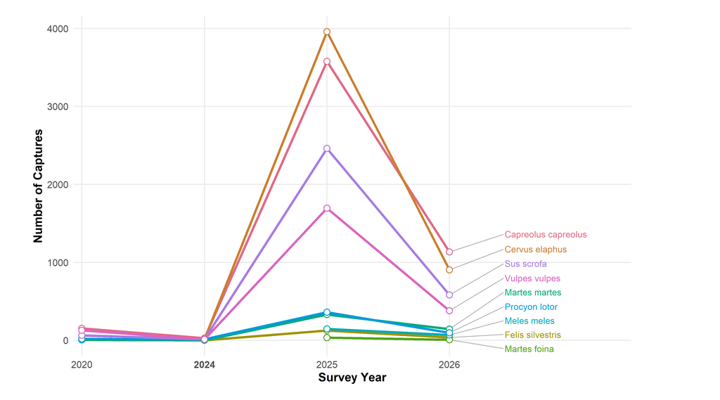

**Figure 3.** *Trends in camera-trap detections over the survey years for each study species in the large mammals group, based on the number of captures. Bold year labels indicate a gap of more than one year since the previous available survey year.*

### Capture Rate

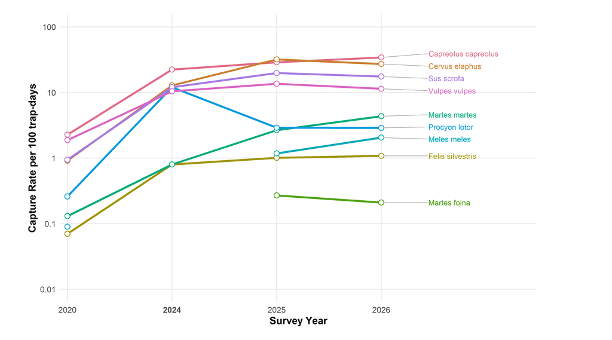

**Figure 4.** *Capture rates per 100 trap-days are shown on a log10 scale for each study species in the large mammals group across survey years. Bold year labels indicate a gap of more than one year since the previous available survey year.*

### Number of Locations

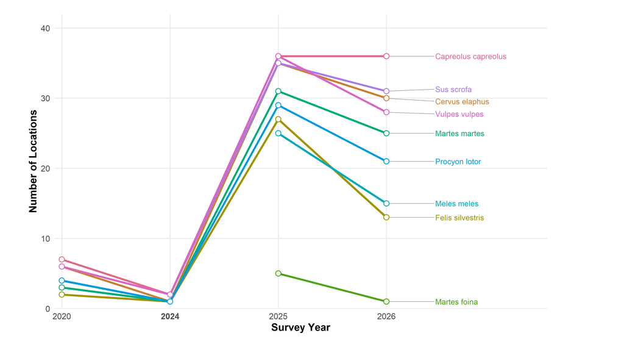

**Figure 5.** *Trends in the number of camera-trap locations where each species was recorded in the large mammals group across survey years. Bold year labels indicate a gap of more than one year since the previous available survey year.*

### REM-Based Density

REM-based density estimates are not available for the selected species.

## 3.3 Population Density Estimation

### 3.3.1 REM Model Parameters

The REM relies on three key parameters: movement speed, activity level, and day range. Movement speed represents the average distance travelled by an individual over time, whereas activity level reflects the proportion of time individuals are active and therefore available for detection by camera traps. Day range refers to the total distance an animal typically moves within a 24-hour period and is derived from movement speed and activity level (Rowcliffe et al., 2008; Rowcliffe et al., 2016). Together, these parameters underpin the REM density estimates presented in this section. The tabs below show species-specific estimates for each parameter.

REM model parameters are not available for the selected species.

## 3.4 Activity Patterns

Activity patterns describe the temporal distribution of animal activity across the 24-hour day and are typically inferred from the timing of camera-trap detections. These patterns help identify whether species are primarily diurnal, nocturnal, or crepuscular, and can provide insight into daily behavior, ecological roles, and potential responses to environmental factors or human disturbance. The figures below present estimated daily activity curves for each study species, based on camera-trap detections collected across the monitoring period and derived using functionality from the activity R package (*Rowcliffe, 2016*).

### Capreolus capreolus

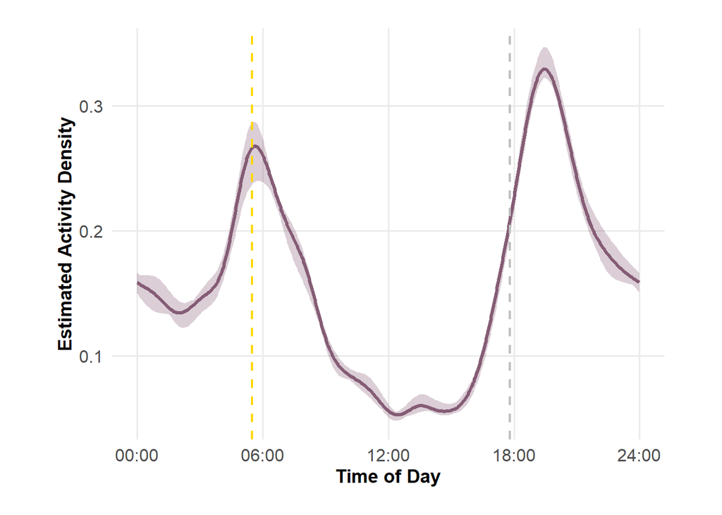

**Figure.6**: *Estimated daily activity pattern for Capreolus capreolus, aggregated across all sampling rounds. Dashed lines indicate the average sunrise (yellow) and sunset (gray) times across survey years. The solid line shows the fitted activity model, and the shaded region shows the 95% CI.*

### Cervus elaphus

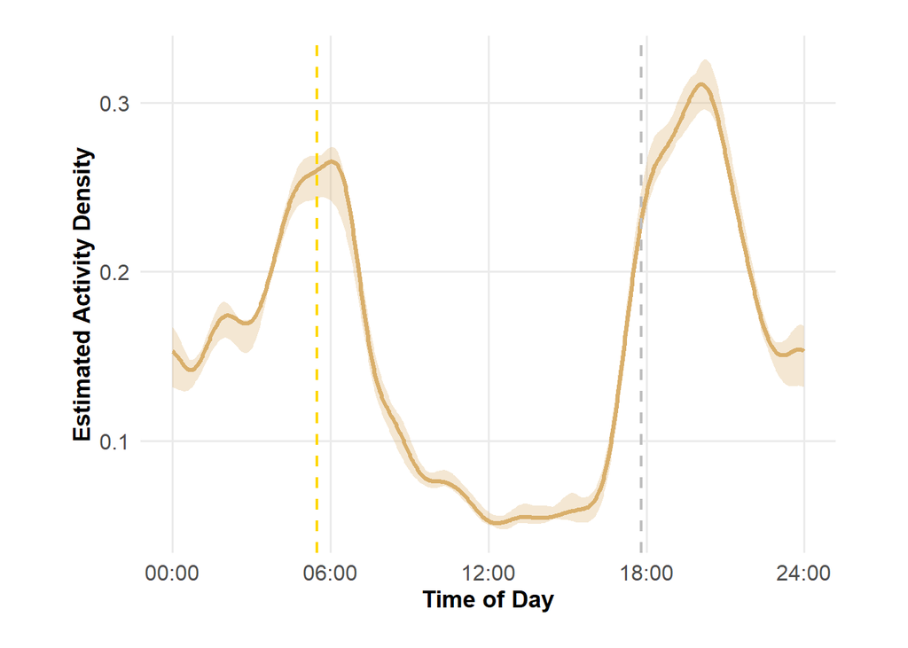

**Figure.7**: *Estimated daily activity pattern for Cervus elaphus, aggregated across all sampling rounds. Dashed lines indicate the average sunrise (yellow) and sunset (gray) times across survey years. The solid line shows the fitted activity model, and the shaded region shows the 95% CI.*

### Felis silvestris

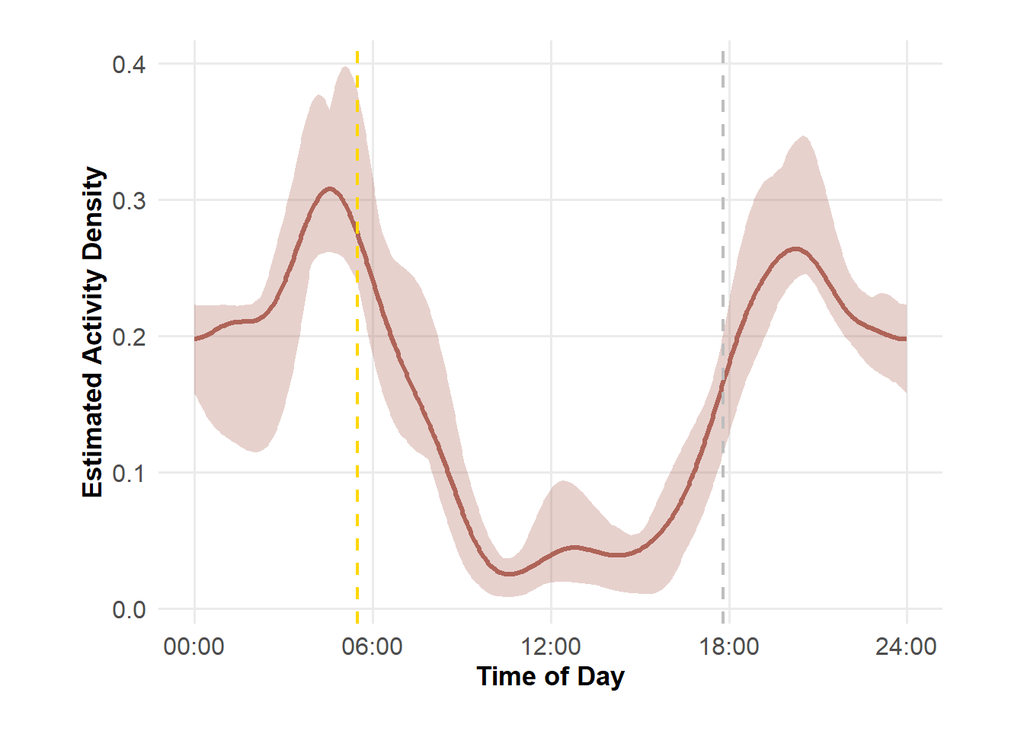

**Figure.8**: *Estimated daily activity pattern for Felis silvestris, aggregated across all sampling rounds. Dashed lines indicate the average sunrise (yellow) and sunset (gray) times across survey years. The solid line shows the fitted activity model, and the shaded region shows the 95% CI.*

### Martes foina

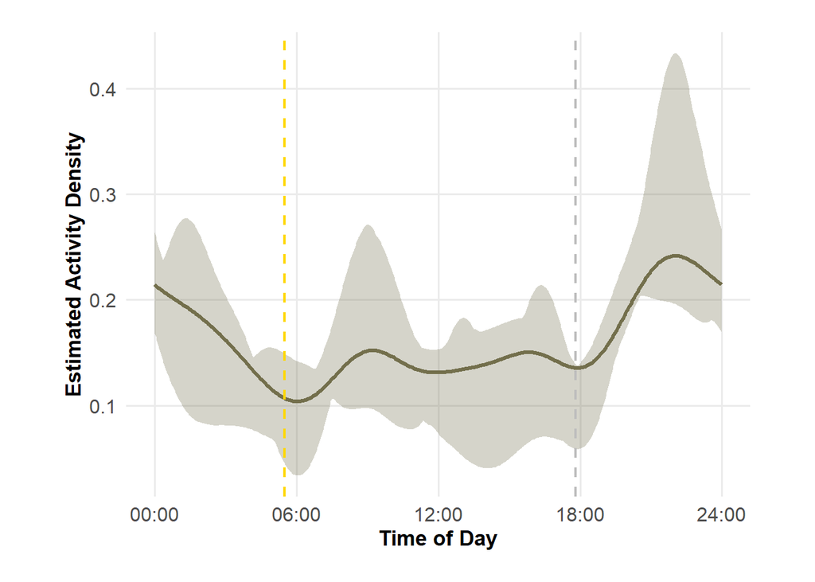

**Figure.9**: *Estimated daily activity pattern for Martes foina, aggregated across all sampling rounds. Dashed lines indicate the average sunrise (yellow) and sunset (gray) times across survey years. The solid line shows the fitted activity model, and the shaded region shows the 95% CI.*

### Martes martes

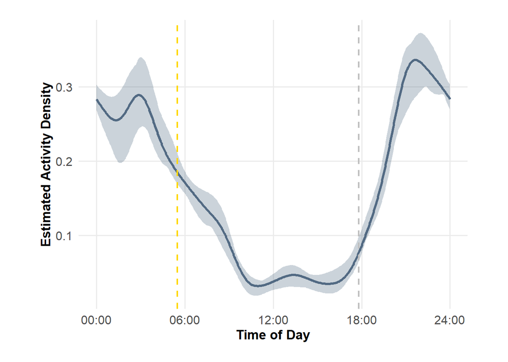

**Figure.10**: *Estimated daily activity pattern for Martes martes, aggregated across all sampling rounds. Dashed lines indicate the average sunrise (yellow) and sunset (gray) times across survey years. The solid line shows the fitted activity model, and the shaded region shows the 95% CI.*

### Meles meles

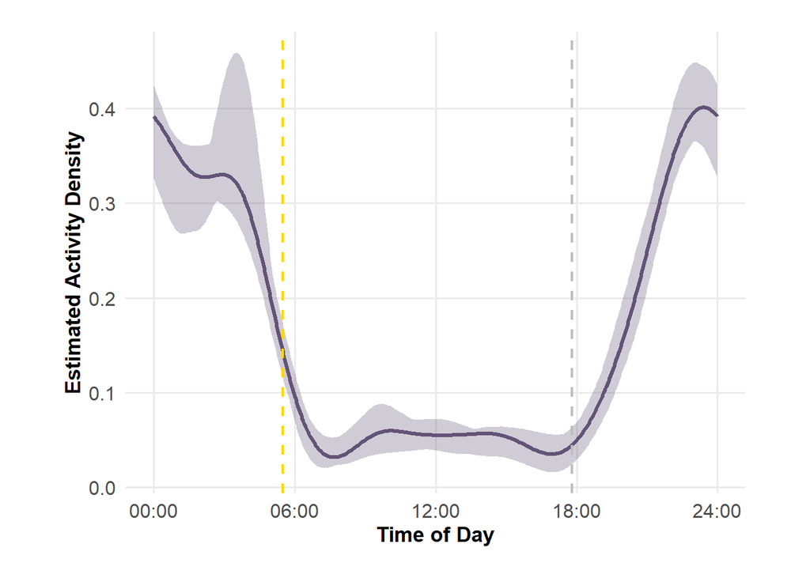

**Figure.11**: *Estimated daily activity pattern for Meles meles, aggregated across all sampling rounds. Dashed lines indicate the average sunrise (yellow) and sunset (gray) times across survey years. The solid line shows the fitted activity model, and the shaded region shows the 95% CI.*

### Procyon lotor

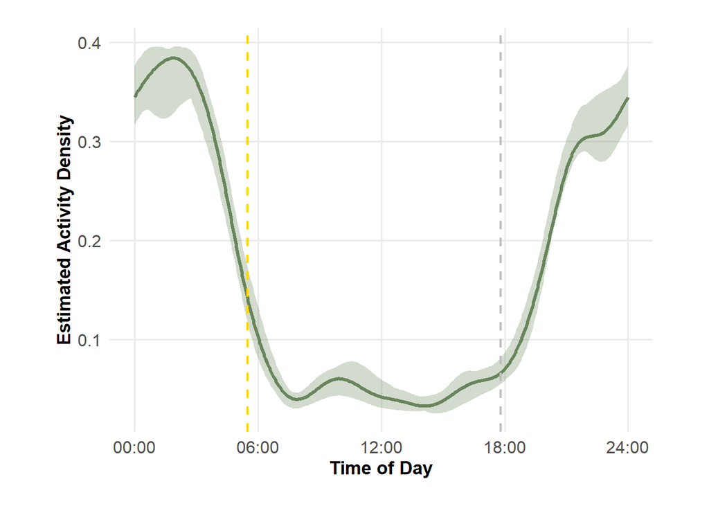

**Figure.12**: *Estimated daily activity pattern for Procyon lotor, aggregated across all sampling rounds. Dashed lines indicate the average sunrise (yellow) and sunset (gray) times across survey years. The solid line shows the fitted activity model, and the shaded region shows the 95% CI.*

### Sus scrofa

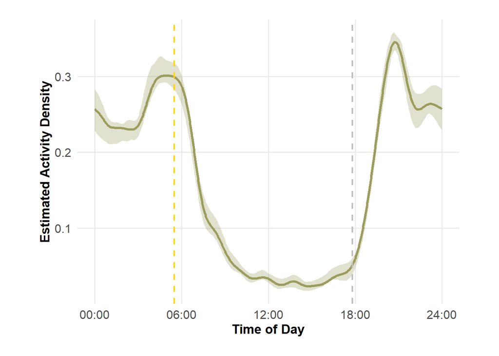

**Figure.13**: *Estimated daily activity pattern for Sus scrofa, aggregated across all sampling rounds. Dashed lines indicate the average sunrise (yellow) and sunset (gray) times across survey years. The solid line shows the fitted activity model, and the shaded region shows the 95% CI.*

### Vulpes vulpes

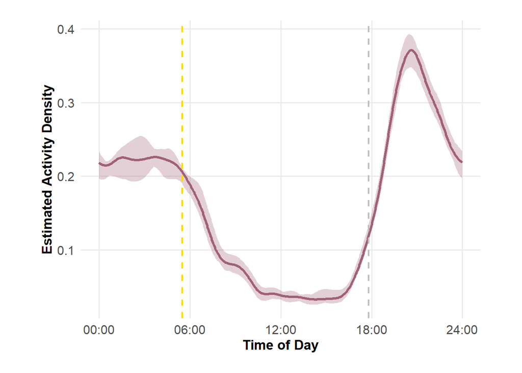

**Figure.14**: *Estimated daily activity pattern for Vulpes vulpes, aggregated across all sampling rounds. Dashed lines indicate the average sunrise (yellow) and sunset (gray) times across survey years. The solid line shows the fitted activity model, and the shaded region shows the 95% CI.*

## 3.5 Richness

Species richness refers to the number of unique species recorded at each camera-trap location. It provides a useful indicator of local biodiversity and helps assess how effectively the survey captured variation in the wildlife community across the study area. The figure below shows the spatial distribution of species richness, where each point represents a camera-trap location. Circle size reflects the number of unique species detected at that site, and color indicates richness intensity, with warmer colors representing higher richness values. By selecting a point, users can view additional information on species composition, richness count, and habitat type, if available. These features help identify biodiversity hotspots and potential detection gaps across the study area.

### 2020

[interactive chart not shown]

**Figure.15**: *Species richness based on the species focus group in this report, across camera-trap locations for survey year 2020.*

### 2024

[interactive chart not shown]

**Figure.16**: *Species richness based on the species focus group in this report, across camera-trap locations for survey year 2024.*

### 2025

[interactive chart not shown]

**Figure.17**: *Species richness based on the species focus group in this report, across camera-trap locations for survey year 2025.*

### 2026

[interactive chart not shown]

**Figure.18**: *Species richness based on the species focus group in this report, across camera-trap locations for survey year 2026.*

### Total

[interactive chart not shown]

**Figure.19**: *Species richness based on the species focus group in this report, across camera-trap locations for the cumulative dataset across all years.*

## 3.6 Species Co-occurrence

Species co-occurrence analysis was used to assess pairwise associations among species recorded across camera-trap locations. Relationships were summarized in a correlation matrix, where positive values indicate species pairs that tended to co-occur more frequently across sites and negative values indicate lower co-occurrence. Such patterns can provide insight into shared space use or spatial segregation among species, although they should be interpreted cautiously because co-occurrence alone does not imply direct interaction. (*Gotelli, 2000*).

### 2020

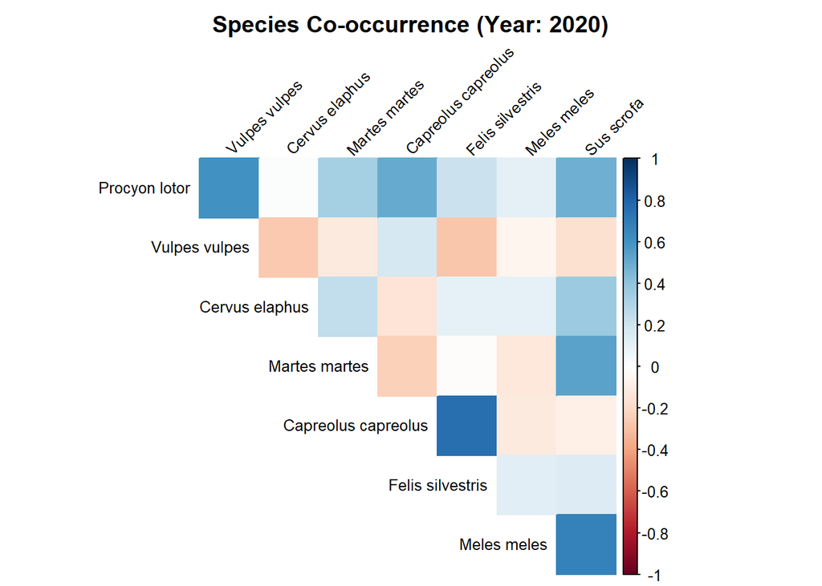

**Figure.20**: *Species co-occurrence patterns for the selected species focus group in this report, shown for survey year 2020.*

### 2024

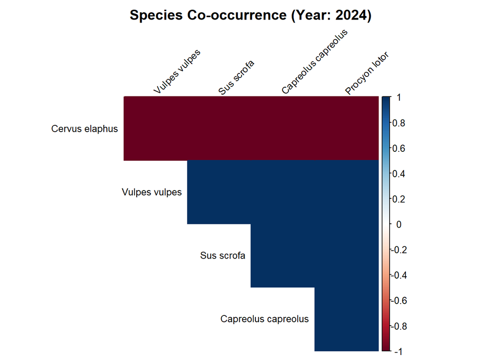

**Figure.21**: *Species co-occurrence patterns for the selected species focus group in this report, shown for survey year 2024.*

### 2025

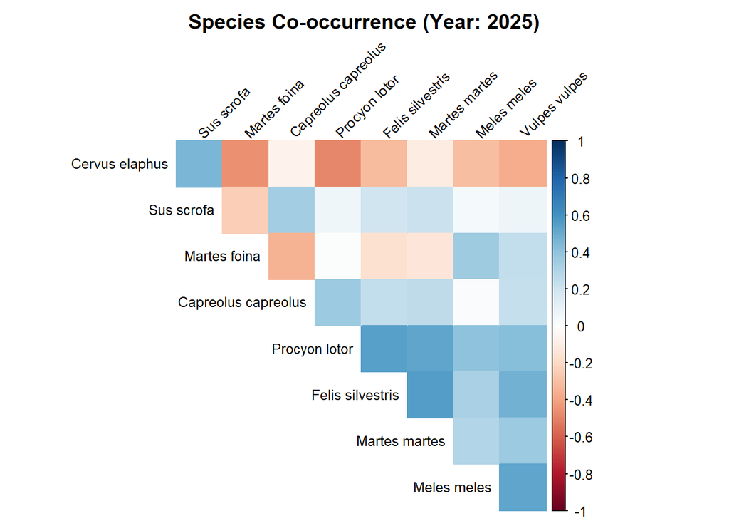

**Figure.22**: *Species co-occurrence patterns for the selected species focus group in this report, shown for survey year 2025.*

### 2026

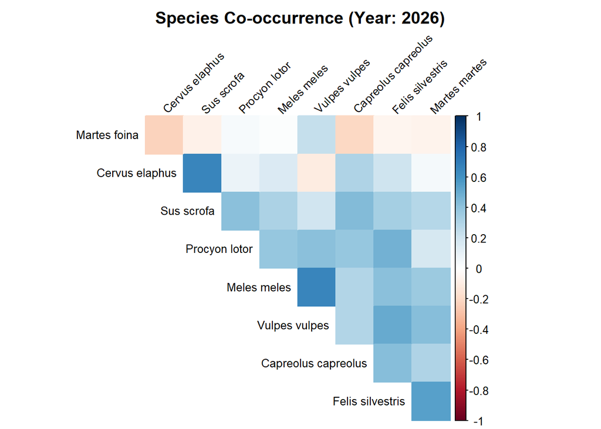

**Figure.23**: *Species co-occurrence patterns for the selected species focus group in this report, shown for survey year 2026.*

### Total

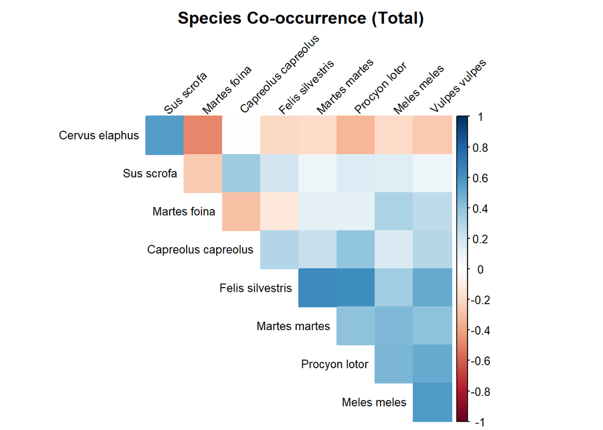

**Figure.24**: *Species co-occurrence patterns for the selected species focus group in this report, shown for the cumulative dataset across all years.*

### 2020

### 2025

### 2026

## 3.8 Habitat Preferences

Habitat preferences were assessed by comparing proportional capture rates across habitat types for each species. Capture rate, expressed as detections relative to sampling effort, serves here as an indicator of habitat use and relative habitat association rather than a direct estimate of habitat selection. Differences in the distribution of capture rates among habitat types therefore highlight habitats in which species were more or less frequently recorded. Together, these patterns provide insight into species-specific habitat use within the study area and help identify broad differences in habitat association among the focal species.

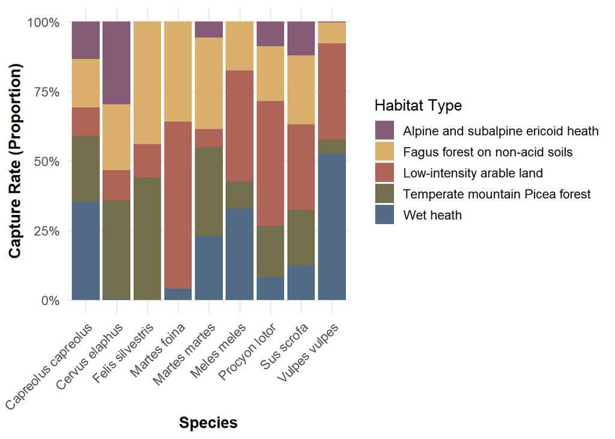

**Figure.25**: *Capture rate distribution across habitat types based on the species focus group. Each bar represents a species, with sections indicating the proportion of each habitat type.*

## 3.9 Species Accumulation Curves

Species accumulation curves show how recorded species richness changes with sampling effort, measured here as the number of camera-trap deployments. For each year available for this site, curves were derived from species presence–absence across deployments using the [iNEXT](https://cran.r-project.org/web/packages/iNEXT/index.html) R package. The tabs below show yearly curves with 95% confidence intervals, and the final Comparison tab overlays years with sufficient data.

### 2020

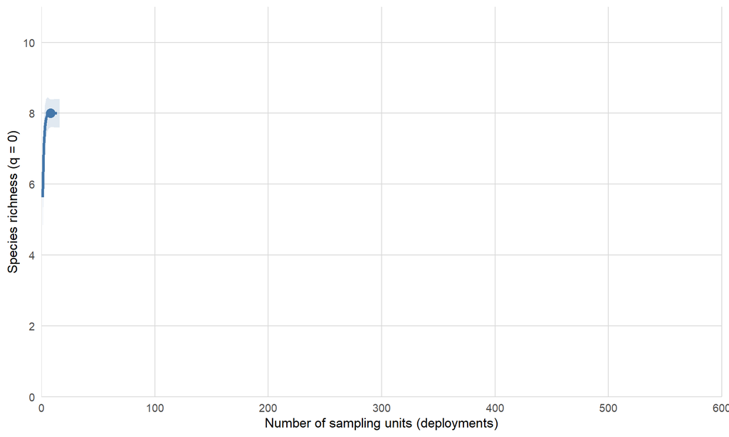

**Figure.26**: *Species accumulation curve for the focal species group in 2020, with 95% confidence interval.*

### 2024

! iNEXT failed for year 2024: NA/NaN argument

### 2025

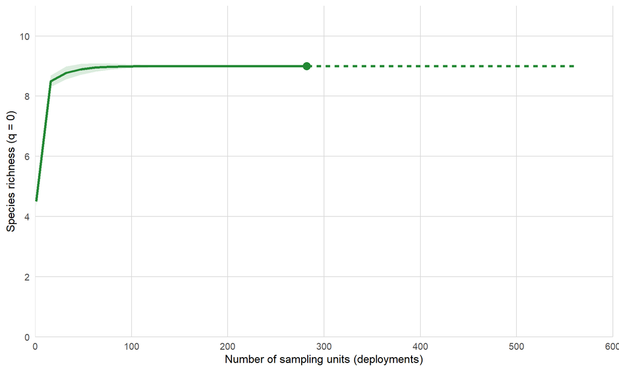

**Figure.27**: *Species accumulation curve for the focal species group in 2025, with 95% confidence interval.*

### 2026

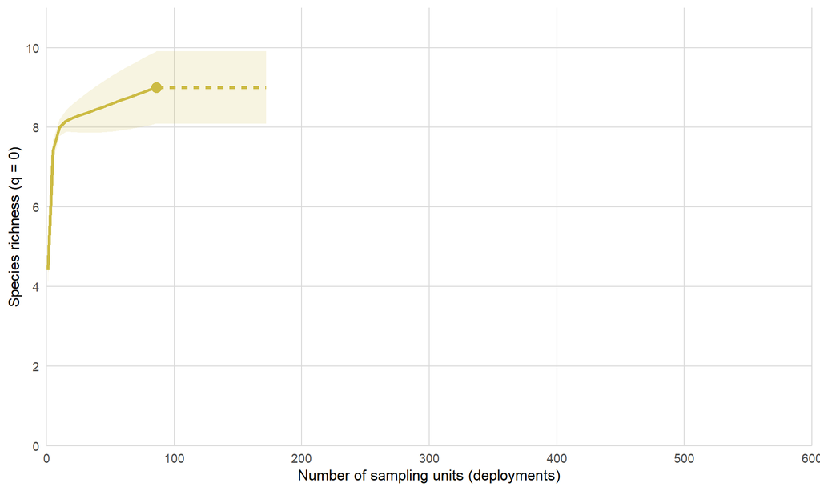

**Figure.28**: *Species accumulation curve for the focal species group in 2026, with 95% confidence interval.*

### Comparison

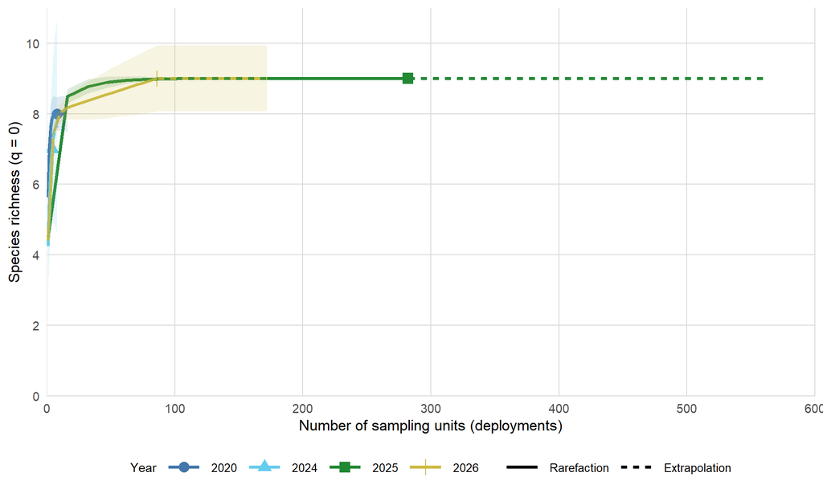

**Figure.29**: *Species accumulation curves by year for the focal species group. Solid lines indicate rarefaction, dashed lines extrapolation, and points observed sample size.*

# 4 Acknowledgements

This report was generated using the [*camtrapReport*](https://github.com/spatialecology/camtrapReport) R package, developed by Elham Ebrahimi at [Wageningen University & Research](https://www.wur.nl/en/persons/e-elham-ebrahimi) and [Utrecht University](https://www.uu.nl/staff/EEbrahimi), the Netherlands. The development of *camtrapReport* was supported by [Biodiversa+](https://www.biodiversa.eu/2022/10/07/2022-2023-joint-call/) through the [Big Picture project](https://wildlifecamera.eu/). We also gratefully acknowledge the [European Observatory of Wildlife](https://wildlifeobservatory.org/) network for its contribution to package testing. Users are kindly requested to [cite the package](https://zenodo.org/records/18405441) when using *camtrapReport* or publishing results derived from it.

# Appendix

The following images showcase a selection of 8 species: *Capreolus capreolus*, *Cervus elaphus*, *Felis silvestris*, *Martes martes*, *Meles meles*, *Procyon lotor*, *Sus scrofa*, *Vulpes vulpes*, captured at different camera locations within this study site.

[figure not shown]

[figure not shown]

[figure not shown]

[figure not shown]

[figure not shown]

[figure not shown]

[figure not shown]

[figure not shown]

# References

- Bubnicki, J. W. et al. (2024). Camtrap DP: an open standard for the FAIR exchange and archiving of camera trap data. *Remote Sensing in Ecology and Conservation*, 10, 283–295. https://doi.org/10.1002/rse2.374
- Casaer, J. et al. (2019). Agouti: A platform for processing and archiving of camera trap images. *Biodiversity Information Science and Standards*, 3, e46690. https://doi.org/10.3897/biss.3.46690
- Coad, L. et al. (2015). Measuring impact of protected area management interventions: current and future use of the Global Database of Protected Area Management Effectiveness. *Philosophical Transactions of the Royal Society B: Biological Sciences*, 370. https://doi.org/10.1098/rstb.2014.0281
- Dirzo, R. et al. (2014). Defaunation in the Anthropocene. *Science*, 345, 401–406. https://doi.org/10.1126/science.1251817
- Gotelli, N. J. (2000). Null model analysis of species co-occurrence patterns. *Ecology*, 81, 2606–2621. https://doi.org/10.1890/0012-9658(2000)081[2606:NMAOSC]2.0.CO;2
- Kays, R. et al. (2009). Camera traps as sensor networks for monitoring animal communities. In *2009 IEEE 34th Conference on Local Computer Networks*, 811–818. https://doi.org/10.1109/LCN.2009.5355046
- Newbold, T. et al. (2015). Global effects of land use on local terrestrial biodiversity. *Nature*, 520, 45–50. https://doi.org/10.1038/nature14324
- O’Connell, A. F. et al. (2011). *Camera traps in animal ecology: methods and analyses*. Springer. https://doi.org/10.1007/978-4-431-99495-4
- Palencia, P. et al. (2022). Random encounter model is a reliable method for estimating population density of multiple species using camera traps. *Remote Sensing in Ecology and Conservation*, 8, 670–682. https://doi.org/10.1002/rse2.269
- Rowcliffe, J. M. et al. (2008). Estimating animal density using camera traps without the need for individual recognition. *Journal of Applied Ecology*, 1228–1236. https://doi.org/10.1111/2041-210X.12278
- Rowcliffe, M. & Rowcliffe, M. M. (2016). *Package ‘activity’*. Animal activity statistics R package version, 1(10.32614). https://doi.org/10.32614/CRAN.package.activity